# Investigating Hospital Appointment "No Shows" in Brazil

1. Intoduction
2. Data Cleaning
   - 2.1 Initial Inspection
   - 2.2 Data Cleaning - High Level
   - 2.3 Data Cleaning - Types
3. Data Exploring
   - 3.1 Time Between Scheduling Day and Appointment Day
     - 3.1.1 Process
     - 3.1.2 Results -3.2 Gender
     - 3.2.1 Process
     - 3.2.2 Results
     - 3.2.3 Additional Analysis
   - 3.3 Repeat Offenders
     - 3.3.1 Process
     - 3.3.2 Results
4. Conclusion References

## 1. Introduction

We shall be looking at data from several Brazilian hospitals, who have collected data around patient appointments. The data looks at various patient factors and whether or not the appointment was attended (or was there a 'no-show'). We shall specifically investigate whether the time between scheduling and the actual appointment affects a patients chance of not attending, whether gender and other binary factors have an affect and lastly, whether a patient who has missed an appointment before, is likely to do so again.

```python
%matplotlib inline
import numpy as np
import pandas as pd
import matplotlib.pyplot as plt
import seaborn as sns
import math
```

## 2. Data Wrangling

### 2.1 Initial Inspection

Initially the data is imported from the csv file into a dataframe and some simple queries are done to check:

- what data does the dataset contain?
- what types are contained in the dataset?
- are there any missing cells?

```python
file_name = "No_show_appt_data.csv"
appt_df = pd.read_csv(file_name)
appt_df.info()
```

```
<class 'pandas.core.frame.DataFrame'>
RangeIndex: 110527 entries, 0 to 110526
Data columns (total 14 columns):
PatientId         110527 non-null float64
AppointmentID     110527 non-null int64
Gender            110527 non-null object
ScheduledDay      110527 non-null object
AppointmentDay    110527 non-null object
Age               110527 non-null int64
Neighbourhood     110527 non-null object
Scholarship       110527 non-null int64
Hipertension      110527 non-null int64
Diabetes          110527 non-null int64
Alcoholism        110527 non-null int64
Handcap           110527 non-null int64
SMS_received      110527 non-null int64
No-show           110527 non-null object
dtypes: float64(1), int64(8), object(5)
memory usage: 11.8+ MB
```

This is good at first glance - there does not seem to be any missing values as all cells contain a non-null entry.

### 2.2 Data Cleaning: High Level

The next step is to check on a high level how clean the data is in each column. Specifically:

- Are there multiple appointments for a single patient?
- Are there duplicate appointments?
- Are there only two unique entries for gender?
- How many neighbourhoods do we have?
- What is the range of unique ages - ie. are all ages realistic?

```python
print('PatientID: ' + str(len(appt_df.PatientId.unique()))) # prints the unique number of patient IDs
print('AppointmentID: ' + str(len(appt_df.AppointmentID.unique()))) #prints the unique number of AppointmentIDs
print('Gender: ' + str(len(appt_df.Gender.unique()))) # prints the unique number of gender entries - this should be 2
print('Age: ' + str(len(appt_df.Age.unique()))) #prints the unique number of age entries
print('Neighbourhood: ' + str(len(appt_df.Neighbourhood.unique()))) # prints the unique number of neighbourhood entries
print(np.sort(appt_df.Age.unique())) # returns a sorted array of unique ages, so we can check for outliers
```

```
PatientID: 61744
AppointmentID: 110527
Gender: 2
Age: 104
Neighbourhood: 81
[ -1   0   1   2   3   4   5   6   7   8   9  10  11  12  13  14  15  16
  17  18  19  20  21  22  23  24  25  26  27  28  29  30  31  32  33  34
  35  36  37  38  39  40  41  42  43  44  45  46  47  48  49  50  51  52
  53  54  55  56  57  58  59  60  61  62  63  64  65  66  67  68  69  70
  71  72  73  74  75  76  77  78  79  80  81  82  83  84  85  86  87  88
  89  90  91  92  93  94  95  96  97  98  99 100 102 115]
```

There do seem to be multiple entries for single patients as the unique number of Patient IDs is much less than the Appointment IDs but there does not seem to be any duplicate Appointment IDs, so we shall assume for now this is not an error. The gender column also seems clean, as there are only two unique entries and we now know we have 81 neighbourhoods.

The range for ages is not correct though - you cannot be less than 0 years old and 115 seems unlikely. Upon further research, according to Wikipedia's list of Verified Oldest People[1], there are 44 people who have lived to 115 or older and some of them did reside in Brazil. So despite the fact that it is unlikely, it cannot be categorically stated that it would be impossible to have a patient who is 115, so we will leave them in the dataset. This leaves us to deal with the entries where age is less than 0

```python
appt_by_age = appt_df.groupby('Age')
print(appt_by_age.get_group(-1)) # groups by age so we can see how many entries have an age of -1.
```

```
          PatientId  AppointmentID Gender          ScheduledDay  \
99832  4.659430e+14        5775010      F  2016-06-06T08:58:13Z

             AppointmentDay  Age Neighbourhood  Scholarship  Hipertension  \
99832  2016-06-06T00:00:00Z   -1         ROMÃO            0             0

       Diabetes  Alcoholism  Handcap  SMS_received No-show
99832         0           0        0             0      No
```

Because there is only one record where the age is less than one, we shall simply exclude it from the database. GIven we have 110,527 records, it is unlikely to influence the results.

```python
appt_clean_df1 = appt_df[appt_df.Age != -1] # removes the entries where age = -1
```

Given that we have a dataset that seems sensible, we can go on to formatting the columns to a more usable format

### 2.3 Data Cleaning - Types

The only obvious type that should be changed is the 'ScheduledDay' and 'AppointmentDay' to a date time format so that we can easily manipulate the values

```python
# this converts the Scheduled Day into a date time type. A new dataframe is created to avoid confusion with the old one.
clean_date = pd.to_datetime(appt_clean_df1['ScheduledDay'],format = '%Y-%m-%dT%H:%M:%SZ')
appt_clean_df2 = appt_clean_df1.drop('ScheduledDay', axis = 1)
appt_clean_df2['ScheduledDay2'] = clean_date
```

```python
#this is the same as for Schedule Day, just applied to the AppointmentDay column
clean_date = pd.to_datetime(appt_clean_df1['AppointmentDay'],format = '%Y-%m-%dT%H:%M:%SZ')
appt_clean_df3 = appt_clean_df2.drop('AppointmentDay', axis = 1)
appt_clean_df3['AppointmentDay2'] = clean_date
```

## 3. Data Exploring

We shall be looking to see if there are any factors that affect the chance of a "No Show." We shall look at three different avenues - the time between schedule day and appointment day, the effects of gender (which we shall then generalise for the other binary inputs) and finally whether patients are likely to be repeat offenders

### 3.1 Time Between Scheduling Day and Appointment Day

Given that we have both when the appointment was scheduled and when it was attended (or not), it seems sensible to look at whether the time between the two makes a difference. Do patients forgot or does their need to see a doctor dimish, the longer between scheduling and the appointment?

#### 3.1.1 Process

We shall start by finding the difference between the Schedule Day and Appointment Day

```python
# this takes the difference between the ScheduleDay and AppointmentDay and standardises it to a day.
diff_schedule_apptm = (appt_clean_df3['AppointmentDay2'] - appt_clean_df3['ScheduledDay2'])/(pd.Timedelta('1 days'))
appt_clean_df3['Diff_Schedule_Appt'] = diff_schedule_apptm
appt_clean_df3.describe()
```

|  | PatientId | AppointmentID | Age | Scholarship | Hipertension | Diabetes | Alcoholism | Handcap | SMS_received | Diff_Schedule_Appt |
| --- | --- | --- | --- | --- | --- | --- | --- | --- | --- | --- |
| count | 1.105260e+05 | 1.105260e+05 | 110526.000000 | 110526.000000 | 110526.000000 | 110526.000000 | 110526.000000 | 110526.000000 | 110526.000000 | 110526.000000 |
| mean | 1.474934e+14 | 5.675304e+06 | 37.089219 | 0.098266 | 0.197248 | 0.071865 | 0.030400 | 0.022248 | 0.321029 | 9.714376 |
| std | 2.560943e+14 | 7.129544e+04 | 23.110026 | 0.297676 | 0.397923 | 0.258266 | 0.171686 | 0.161543 | 0.466874 | 15.244112 |
| min | 3.920000e+04 | 5.030230e+06 | 0.000000 | 0.000000 | 0.000000 | 0.000000 | 0.000000 | 0.000000 | 0.000000 | -6.575926 |
| 25% | 4.172538e+12 | 5.640285e+06 | 18.000000 | 0.000000 | 0.000000 | 0.000000 | 0.000000 | 0.000000 | 0.000000 | -0.346157 |
| 50% | 3.173180e+13 | 5.680572e+06 | 37.000000 | 0.000000 | 0.000000 | 0.000000 | 0.000000 | 0.000000 | 0.000000 | 3.473993 |
| 75% | 9.438960e+13 | 5.725523e+06 | 55.000000 | 0.000000 | 0.000000 | 0.000000 | 0.000000 | 0.000000 | 1.000000 | 14.320576 |
| max | 9.999820e+14 | 5.790484e+06 | 115.000000 | 1.000000 | 1.000000 | 1.000000 | 1.000000 | 4.000000 | 1.000000 | 178.554873 |

Looking at the results, we have some entries where the difference is less than 0. Some of these could be explained by the fact that the Schedule Day column has a date and time whilst the Appointment Day column only records a day. Thus, if a patient booked on the same day as he or she was due to attend, there would be a difference less than 0 but more than -1. So we shall focus our efforts on entries where the difference between the two days is less than -1. Because there are only 5 of them, we shall delete those rows, as it will not significantly influence our sample, given the large size (110,526).

```python
appt_clean_df4 = appt_clean_df3[appt_clean_df3.Diff_Schedule_Appt > -1]
numbers = appt_clean_df4._get_numeric_data()
numbers[numbers <0]=0
appt_clean_df4.describe()
```

|  | PatientId | AppointmentID | Age | Scholarship | Hipertension | Diabetes | Alcoholism | Handcap | SMS_received | Diff_Schedule_Appt |
| --- | --- | --- | --- | --- | --- | --- | --- | --- | --- | --- |
| count | 1.105210e+05 | 1.105210e+05 | 110521.000000 | 110521.000000 | 110521.000000 | 110521.000000 | 110521.000000 | 110521.000000 | 110521.000000 | 110521.000000 |
| mean | 1.474906e+14 | 5.675304e+06 | 37.089386 | 0.098271 | 0.197257 | 0.071869 | 0.030401 | 0.022231 | 0.321043 | 9.870377 |
| std | 2.560860e+14 | 7.129691e+04 | 23.109885 | 0.297682 | 0.397929 | 0.258272 | 0.171690 | 0.161494 | 0.466879 | 15.141571 |
| min | 3.920000e+04 | 5.030230e+06 | 0.000000 | 0.000000 | 0.000000 | 0.000000 | 0.000000 | 0.000000 | 0.000000 | 0.000000 |
| 25% | 4.172460e+12 | 5.640284e+06 | 18.000000 | 0.000000 | 0.000000 | 0.000000 | 0.000000 | 0.000000 | 0.000000 | 0.000000 |
| 50% | 3.173180e+13 | 5.680573e+06 | 37.000000 | 0.000000 | 0.000000 | 0.000000 | 0.000000 | 0.000000 | 0.000000 | 3.475012 |
| 75% | 9.438960e+13 | 5.725524e+06 | 55.000000 | 0.000000 | 0.000000 | 0.000000 | 0.000000 | 0.000000 | 1.000000 | 14.320648 |
| max | 9.999820e+14 | 5.790484e+06 | 115.000000 | 1.000000 | 1.000000 | 1.000000 | 1.000000 | 4.000000 | 1.000000 | 178.554873 |

```python
""" Create a new database, grouped by no-show,
with just the columns we are interested in, to make the data analysis easier to navigate"""
diff_schedule_appt_no_show_df = appt_clean_df4.loc[:,['No-show','Diff_Schedule_Appt']]
diff_schedule_appt_by_noshow_df = diff_schedule_appt_no_show_df.groupby('No-show')
```

#### 3.1.2 Results

```python
diff_schedule_appt_by_noshow_df.describe()
```

| No-show | Diff_Schedule_Appt count | Diff_Schedule_Appt mean | Diff_Schedule_Appt std | Diff_Schedule_Appt min | Diff_Schedule_Appt 25% | Diff_Schedule_Appt 50% | Diff_Schedule_Appt 75% | Diff_Schedule_Appt max |
| --- | --- | --- | --- | --- | --- | --- | --- | --- |
| No | 88207.0 | 8.475133 | 14.429277 | 0.0 | 0.000000 | 1.622755 | 11.643021 | 178.553681 |
| Yes | 22314.0 | 15.385762 | 16.565811 | 0.0 | 3.451548 | 10.325955 | 22.656308 | 178.554873 |

Looking at the results, it seems that an increase in time between scheduling and attendance might affect a patient's chance of not showing up, as the mean for a no-show is almost double that of the shows. To see if this is significant and could represent the entire population, we need to find the t-test statistic for an independent sample.

```python
# finding the means of our 'no-shows' and 'shows'
mean_no = diff_schedule_appt_by_noshow_df.mean().iloc[0][0]
mean_yes = diff_schedule_appt_by_noshow_df.mean().iloc[1][0]
# sample size for 'no-show' and 'shows'
n_no = diff_schedule_appt_by_noshow_df.count().iloc[0][0]
n_yes = diff_schedule_appt_by_noshow_df.count().iloc[1][0]
# finding the standard deviation
stdev_no = diff_schedule_appt_by_noshow_df.std().iloc[0][0]
stdev_yes = diff_schedule_appt_by_noshow_df.std().iloc[1][0]
# calculate standard error
SEM = math.sqrt((stdev_no*stdev_no/n_no)+(stdev_yes*stdev_yes/n_yes))
# finally, calculate the t_statistic
t_statistic = (mean_no - mean_yes)/SEM

print('t statistic: ' + str(t_statistic))
```

```
t statistic: -57.0779793615
```

Given that this t value is much higher than the critical t value for a single tail test with alpha = 0.05 (-1.645), we can assume that it is likely that an increase in time between scheduled day and appointment day may contribute to a patient not attending an appointment. To see how much it may influence it, we look at the coefficient of determinations.

```python
r_2 = (t_statistic*t_statistic)/(t_statistic*t_statistic + (n_no + n_yes - 2))
print('coefficient of determination: ' + str(r_2))
```

```
coefficient of determination: 0.0286340711543
```

The coefficient of determinations shows that only approximately 2.8% may be attributed to the difference in schedule and appointment day

### 3.2 Gender

Does the gender of the patient influence the chance of a patient not showing up for an appointment? Are either men or woman more or less likely to attend their scheduled appointment?

#### 3.2.1 Process

We shall start by finding the percent of no-shows that male and females and likewise the percent of 'shows' that are male/female.

```python
#extract the data for gender and no-show from the clean dataframe
F_no_show = len(appt_clean_df4[(appt_clean_df4['Gender'] == 'F') & (appt_clean_df4['No-show'] == 'No')])
F_show = len(appt_clean_df4[(appt_clean_df4['Gender'] == 'F') & (appt_clean_df4['No-show'] == 'Yes')])
M_no_show = len(appt_clean_df4[(appt_clean_df4['Gender'] == 'M') & (appt_clean_df4['No-show'] == 'No')])
M_show = len(appt_clean_df4[(appt_clean_df4['Gender'] == 'M') & (appt_clean_df4['No-show'] == 'Yes')])
#check that this total is still the original number of records we started with
total_check = F_no_show + F_show + M_no_show + M_show
print(total_check)
# make a new dataframe with only the data we need
gender = {'Female': pd.Series([F_no_show, F_show], index = ['No-show','Show']), 'Male': pd.Series([M_no_show, M_show],index = ['No-show','Show'])}
gender_df = pd.DataFrame(gender)
# Add columns with numbers expressed as a percent
gender_df['F_percent']=gender_df['Female']/(gender_df.sum(axis = 1))*100
gender_df['M_percent']=gender_df['Male']/(gender_df.sum(axis = 1))*100


print(gender_df)
```

```
110521
         Female   Male  F_percent  M_percent
No-show   57245  30962  64.898477  35.075716
Show      14591   7723  65.389442  34.509431
```

#### 3.2.2 Results

From the below graph we can see there is no noticable difference between male and female patients so it seems reasonable to end the analysis here.

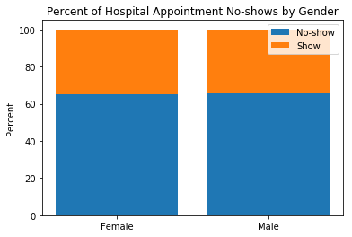

```python
N=2
ind = np.arange(N)
width = 0.4
Female = [gender_df.loc['No-show']['F_percent'],gender_df.loc['Show']['F_percent']]
Male = [gender_df.loc['No-show']['M_percent'],gender_df.loc['Show']['M_percent']]

p1 = plt.bar(ind, Female)
p2 = plt.bar(ind, Male, bottom = Female)
plt.ylabel('Percent')
my_ticks = ['Female', 'Male']
my_ticks_x = [0,1]
plt.xticks(my_ticks_x,my_ticks)
plt.title('Percent of Hospital Appointment No-shows by Gender')
plt.legend((p1[0], p2[0]), ('No-show', 'Show'))
```

#### 3.2.3 Additional Analysis

Given that there are several columns with similar binary states (ie., the column entries can only be one of two entries - for example the 'Scholarship' column), it would make sense to use the gender analysis to write a function that can quickly check whether any of these affect the chance of a no-show. It seems unlikely that whether someone had diabetes or not might influence their chance of attending an appointment but if it can be done quickly it might be worth checking.

```python
def statistically_significant(binary_percent_array):
    """calculates the two tailed t-test statistic for an independent set of data with alpha=0.05
    binary_percent_array should be a 4x4 pandas dataframe with rows 'No-show' and 'Show', with percentages for binary data"""

    #finds the means for the show and no-show data
    mean_no_show = binary_percent_array.mean().iloc[0]
    mean_show = binary_percent_array.mean().iloc[1]
    #finds the sample sizes for show and no-show data
    n_no_show = binary_percent_array.count().iloc[0]
    n_show = binary_percent_array.count().iloc[1]
    #finds the standard deviation for the show and no-show data
    stdev_no_show = binary_percent_array.std().iloc[0]
    stdev_show = binary_percent_array.std().iloc[1]
    # calculate standard error
    SEM = math.sqrt((stdev_no_show*stdev_no_show/n_no_show)+(stdev_show*stdev_show/n_show))
    # calculates the t statistic
    t_statistic = (mean_no_show - mean_show)/SEM
    #t_critical for two-tailed t-test with alpha = 0.05 and df =  inf
    t_crit = 1.960

    if t_statistic > t_crit:
        print('The difference between No-show and Show data is statistically significant - could be causation')
        return True
    else:
        print('The difference between No-show and Show data is NOT statistically significant - causation NOT likely')
        return False
```

```python
def binary_input_on_no_show(df, binary_label, inputa, inputb):
    """a function that takes the clean dataframe (df), a specified column name (binary_label) of a binary entry column
    and the entries that column could take (inputa and inputb)."""
    #First to extract the relevant columns from the dataframe
    a_no_show = len(df[(df[binary_label] == inputa) & (df['No-show'] == 'No')])
    a_show = len(df[(df[binary_label] == inputa) & (df['No-show'] == 'Yes')])
    b_no_show = len(df[(df[binary_label] == inputb) & (df['No-show'] == 'No')])
    b_show = len(df[(df[binary_label] == inputb) & (df['No-show'] == 'Yes')])
    # Then create a new dataframe
    input_ = {inputa: pd.Series([a_no_show, a_show], index = ['No-show','Show']), inputb: pd.Series([b_no_show, b_show],index = ['No-show','Show'])}
    input_df = pd.DataFrame(input_)

    # test for statistical significance
    test = statistically_significant(input_df)

    # if the test could be significant, print a graph
    if test == True:
        # add columns that are percentages
        input_df['a_percent']=input_df[inputa]/(input_df.sum(axis = 1))*100
        input_df['b_percent']=input_df[inputb]/(input_df.sum(axis = 1))*100

        #make column names that relate to input
        input_names = pd.Series([inputa, inputb], index = ['a','b'])
        input_names2 = input_names.replace([0,1],['No','Has'])
        input_names3 = input_names2 + ' ' + binary_label

        print(input_df.loc[:,['a_percent','b_percent']].rename(index=str,columns = {'a_percent': input_names3[0], 'b_percent': input_names3[1]}))

        #set up graph
        N=2
        ind = np.arange(N)
        width = 0.4
        input_a = [input_df.loc['No-show']['a_percent'],input_df.loc['Show']['a_percent']]
        input_b = [input_df.loc['No-show']['b_percent'],input_df.loc['Show']['b_percent']]

        # make plot
        p1 = plt.bar(ind, input_a)
        p2 = plt.bar(ind, input_b, bottom = input_a)
        plt.ylabel('Percent')
        my_ticks = [input_names3[0], input_names3[1]]
        my_ticks_x = [0,1]
        plt.xticks(my_ticks_x,my_ticks)
        title_str = 'Percent of Hospital Appointment No-shows by ' + binary_label
        plt.title(title_str)
        plt.legend((p1[0], p2[0]), ('No-show', 'Show'))
```

Now we can test whether having a Scholarship Programme, Hipertension, Diabetes, Alcoholism, Handcap or receiving a Notice SMS is likely to influence a patients attendance

```python
binary_input_on_no_show(appt_clean_df4, 'Scholarship', 0, 1)
```

```
The difference between No-show and Show data is NOT statistically significant - causation NOT likely
```

```python
binary_input_on_no_show(appt_clean_df4, 'Hipertension', 0, 1)
```

```
The difference between No-show and Show data is NOT statistically significant - causation NOT likely
```

```python
binary_input_on_no_show(appt_clean_df4, 'Diabetes', 0, 1)
```

```
The difference between No-show and Show data is NOT statistically significant - causation NOT likely
```

```python
binary_input_on_no_show(appt_clean_df4, 'Alcoholism', 0, 1)
```

```
The difference between No-show and Show data is NOT statistically significant - causation NOT likely
```

```python
binary_input_on_no_show(appt_clean_df4, 'Handcap', 0, 1)
```

```
The difference between No-show and Show data is NOT statistically significant - causation NOT likely
```

```python
binary_input_on_no_show(appt_clean_df4, 'SMS_received', 0, 1)
```

```
The difference between No-show and Show data is NOT statistically significant - causation NOT likely
```

This shows that most underlying causes do not affect whether a person will show up or not.

### 3.3 Repeat Offenders

Given that we have less unique patients than appointments, is someone more likely to not show up for an appointment, given they have already not attended a previous appointment?

#### 3.3.1 Process

The first step is to isolate only those patients who have scheduled more than one appointment

```python
# isolate the columns from the clean dataframe
patient_df = appt_clean_df4.loc[:, ['PatientId', 'No-show']]
# create a column that counts the number of scheduled appointments per patientID
patient_df['Freq'] = patient_df.groupby('PatientId')['PatientId'].transform('count')
# convert strings to integers to make counting easiers
patient_df['No-show']=patient_df['No-show'].map(dict(Yes=1, No=0))
# count the number of no shows
patient_df['Freq_no_show'] = patient_df.groupby('PatientId')['No-show'].transform('sum')
patient_df = patient_df.drop('No-show',1)
patient_df = patient_df.drop_duplicates()
#create a new database that only has patients who have not show up more than once
outlier_df = patient_df[patient_df['Freq_no_show'] > 1]
outlier_df.head(5)
```

|  | PatientId | Freq | Freq_no_show |
| --- | --- | --- | --- |
| 7 | 3.449830e+12 | 2.0 | 2 |
| 20 | 6.222570e+14 | 2.0 | 2 |
| 21 | 1.215480e+13 | 6.0 | 3 |
| 37 | 1.578130e+12 | 6.0 | 2 |
| 49 | 9.223560e+13 | 2.0 | 2 |

#### 3.3.2 Results

We can now look at the frequency distribution for the no-shows (by patient) and given that the majority of appointments were attended, to only focus on the no-shows

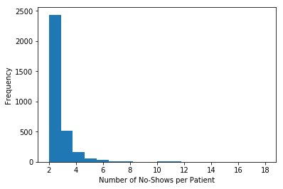

```python
# plot a histogram of frequency
p3 = plt.hist(outlier_df['Freq_no_show'],bins = 18)
plt.ylabel ('Frequency')
plt.xlabel('Number of No-Shows per Patient')
```

This is as we would expect - with the highest frequency being the least number of repeat offenders. But we would like to know what the chance is that, given they have missed the previous appointment, how likely are they to turn up for the next one?

So we need to make a probability distribution

```python
# create a dataframe that counts the frequency of the number of no-shows
unique_values_group = patient_df.groupby('Freq_no_show')
unique_values_dict=(unique_values_group.count())
unique_values_dict['Probability'] = unique_values_dict['Freq']/(unique_values_dict['Freq'].sum())
unique_values_dict['Freq_no_show'] = unique_values_dict.index[:].tolist()
unique_values_dict
```

| Freq_no_show | PatientId | Freq | Probability | Freq_no_show |
| --- | --- | --- | --- | --- |
| 0 | 44123 | 44123 | 0.714624 | 0 |
| 1 | 14367 | 14367 | 0.232690 | 1 |
| 2 | 2438 | 2438 | 0.039486 | 2 |
| 3 | 520 | 520 | 0.008422 | 3 |
| 4 | 164 | 164 | 0.002656 | 4 |
| 5 | 59 | 59 | 0.000956 | 5 |
| 6 | 33 | 33 | 0.000534 | 6 |
| 7 | 13 | 13 | 0.000211 | 7 |
| 8 | 9 | 9 | 0.000146 | 8 |
| 9 | 3 | 3 | 0.000049 | 9 |
| 10 | 4 | 4 | 0.000065 | 10 |
| 11 | 4 | 4 | 0.000065 | 11 |
| 12 | 1 | 1 | 0.000016 | 12 |
| 13 | 1 | 1 | 0.000016 | 13 |
| 14 | 1 | 1 | 0.000016 | 14 |
| 15 | 1 | 1 | 0.000016 | 15 |
| 16 | 1 | 1 | 0.000016 | 16 |
| 18 | 1 | 1 | 0.000016 | 18 |

```python
# counts the total number of no-shows
num_no_show = unique_values_dict[unique_values_dict['Freq_no_show'] > 0]['Freq'].sum()
#calculates the probability of 1 no-show
prob_no_show = num_no_show/(unique_values_dict['Freq'].sum())
# calculates the probability of 2 no-shows
num_no_show_more_once = unique_values_dict[unique_values_dict['Freq_no_show'] > 1]['Freq'].sum()
# calculates the probability of two no shows, given that one has occured
prob_repeat_no_show = num_no_show_more_once/num_no_show
print('Probability of a repeat no-show, given one has occured: ' + str(prob_repeat_no_show))
```

```
Probability of a repeat no-show, given one has occured: 0.18461975028376845
```

This shows that there is an 18.4% chance that, given that a patient has not shown up for a previous appointment, they will not attend the next one. We can now apply this to all instances of no-shows to find the probability distribution.

```python
def likelihood_repeat(df, num):
    """calculates the probability of someone not showing up for an appointment,
    given the number of appointments they have not shown up for previously
    df - pandas DataFrame that contains frequency of no shows and count of these, labelled 'Freq_no_show' and 'Count' respectively
    num - int indicating the number of previous no shows"""
    num_no_show = df[df['Freq_no_show'] > num]['Freq'].sum()
    prob_no_show = num_no_show/(df['Freq'].sum())
    num_no_show_more_once = df[df['Freq_no_show'] > (num + 1)]['Freq'].sum()
    prob_repeat_no_show = num_no_show_more_once/num_no_show
    return prob_repeat_no_show
```

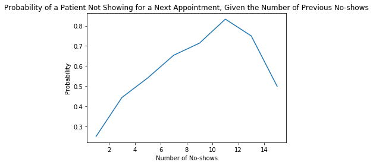

```python
prob_curve_x = []
prob_curve_y = []
for i in range(1,17,2): #add step of 2 for smoothness
    x = likelihood_repeat(unique_values_dict, i)
    prob_curve_x.append(i)
    prob_curve_y.append(x)
p1 = plt.plot(prob_curve_x, prob_curve_y)
plt.title('Probability of a Patient Not Showing for a Next Appointment, Given the Number of Previous No-shows')
plt.ylabel('Probability')
plt.xlabel('Number of No-shows')
```

## 4. Conclusion

From the above analysis we can see that it is statistically likely that the time between scheduling and the actual appointment may impact the chance of a patient not attending their appointment. Although the statistical resulst were very strong, further data would probably be required to prove this. Also, given the size of the data, the coefficient of determination showed the time between scheduling and the appointment and possibility of a no-show has a small correlation.

We also found that neither gender, being on the scholarship programme, having hipertension, diabetes, alcoholism or receiving a notice sms had any statistical significance on wether a patient attends an appointment or not.

This analysis could be useful to the Brazilian hospitals, who could focus their energy on reminding patients who have previously skipped appointments or where there is a long time between scheduling and appointment day.

## References

[1] https://en.wikipedia.org/wiki/List_of_the_verified_oldest_people

```python
from subprocess import call
call(['python', '-m', 'nbconvert', 'P2 Project.ipynb'])
```